# MATH70076: Data Science - Formative Assessment

MSc in Statistics 2026/27, Imperial College London

Author

06121926

**Deadline: Monday 12 October 2026 at 13:00.**

*For this formative assessment you should submit two files via the Imperial College VLE on Canvas by the deadline stated above. Your files should be named as follows:*

- `YOURCID-MATH70076-formative-assessment.pdf`: your rendered report,
- `YOURCID-MATH70076-formative-assessment.zip`: a zip file containing the relevant source code to generate your report.

*All submitted materials should be clearly presented and be understandable as stand-alone documents.*

*Please note that large files can take quite some time to upload. Ensure that you upload each document to the correct part of the learning space in a timely manner.*

*This mock coursework is a formative assessment and so will not contribute to your overall grade for the module. It is designed for you to practice the skills you have learned in the first workshop and to get feedback on your reflective writing style. This activity is expected to take approximately 6 hours of individual effort. Assessment criteria are given in the “set yourself up for success” boxes. Satisfying 18 or more out of these 23 criteria corresponds to a notional “pass” grade.*

*In submitting this mock assessment you certify that it is entirely your own work, apart from where otherwise acknowledged, and includes no plagiarism. Note that software tools are used as part of plagiarism detection.*

## Background

### Generalised Pareto Distribution

The Generalized Pareto Distribution (GPD) is a flexible family of continuous probability distributions that arises naturally in extreme value theory, particularly for modelling the distribution of excesses over a threshold. It is parametrised by a shape parameter $\xi \in \mathbb{R}$, a scale parameter $\sigma > 0$, and a location parameter $u \in \mathbb{R}$. Its cumulative distribution function (CDF) is given by

$$F(x;\,\sigma,\xi, u) =
\begin{cases}
1 - \left(1 + \dfrac{\xi (x-u)}{\sigma}\right)_+^{-1/\xi}, & \xi \neq 0, \, x \geq u; \; \\[1.2em]
1 - \exp\!\left(-\dfrac{x-u}{\sigma}\right), & \xi = 0, \, x \geq u;
\end{cases}
\tag{1}$$

where $x_+ = \max(x,0)$ and its probability density function (PDF) is

$$f(x;\sigma,\xi,u) =
\begin{cases}
\dfrac{1}{\sigma}\left(1 + \dfrac{\xi (x-u)}{\sigma}\right)_+^{-1/\xi - 1}, & \xi \neq 0, \\[1.2em]
\dfrac{1}{\sigma}\exp\!\left(-\dfrac{x-u}{\sigma}\right), & \xi = 0,
\end{cases}
\tag{2}$$

defined on the same support as the CDF. The GPD encompasses a variety of tail behaviours:

- when $\xi > 0$ the GPD has heavy, slowly decaying tails,
- in limiting case when $\xi \rightarrow 0$ the GPD reduces to an exponential distribution;
- when $\xi < 0$ the GPD has light, quickly decaying tails with a finite upper endpoint of $x^+ = u - \sigma / \xi$.

### Probability Integral Transform

The probability integral transform states that if a random variable $X$ has a continuous cumulative distribution function $F_X(x)$, then the transformed variable $A = F_X(X)$ follows a uniform distribution on $[0,1]$. Conversely, if $F$ is an invertible function then $Y = F^{-1}_X(A)$ has the same distribution as $X$.

## Questions

### Question 1

Derive an expression for the inverse cumulative distribution function (also known as the quantile function) $F^{-1}_X: [0,1] \rightarrow [u, x^+]$ of $X \sim \text{GPD}(u, \sigma, \xi)$. Your answer should refer to at least one equation given in the background material.

**TipSet yourself up for success**

Does your answer contain:

- a few sentences of text describing your approach to the problem;
- a reference to at least one equation from the background section;
- a correctly formatted LaTeX equation;
- a valid approach to the problem and correct expression.

The inverse of a function requires the function to be bijective i.e., injective and surjective. So we need to show Equation 1 is bijective.

*Injective*

The CDF Equation 1 needs to be strictly monotonic for it to be injective. We can evaluate its derivative with respect to x and see if the derivative is always greater than zero. Note that

$$F'_X(x; \sigma,\xi,u) = f_X(x;\sigma,\xi,u)$$

Thus we can look at the sign of the PDF Equation 2. Let

$$a\left(x\right)=\frac{1}{\sigma}\left(1+\frac{\xi\left(x-u\right)}{\sigma}\right)_+$$

$$b=-1-1/\xi$$

Note that $a\left(x\right)^b$ is strictly positive if $a\left(x\right)> 0$

1. If $\xi = 0$
   - $f_X$ is positive as $exp^z > 0$ for $\forall z\in\mathbb{R}$.
2. If $\xi < 0$
   - the condition $\left(\;\right)_+$ restricts $x\in\left[\mu, \frac{\sigma}{|\xi|}+\mu\right]$
   - then f is of the form $a\left(x\right)^b$ where $a\left(x\right)\geq0$
   - if $x\in\left[\mu, \frac{\sigma}{|\xi|}+\mu\right)$ then $a\left(x\right)>0$
3. If $\xi>0$
   - then f is of the form $a\left(x\right)^b$ where $a\left(x\right)>0$

Thus the CDF is injective

*Surjective*

Under the three cases of $\xi$, $F_X$ is continuous. The boundaries of the domain are established in order to determine the boundaries of the range.

1. If $\xi = 0$
   - $F_X : \left[\mu,\infty\right)\to\left[0,1\right)$
2. If $\xi < 0$
   - $a\left(\mu\right)= 1$, so $F_X\left(\mu\right)=0$
   - $a\left(\mu-\frac{\sigma}{\xi}\right)= 0$, so $F_X\left(\mu-\frac{\sigma}{\xi}\right)=1$
   - $F_X : \left[\mu,\mu-\frac{\sigma}{\xi}\right)\to\left[0,1\right)$
3. If $\xi>0$
   - $a\left(\mu\right)= 1$, so $F_X\left(\mu\right)=0$
   - $lim_{x\to\infty}F_X\left(x\right)\to1$ as $lim_{x\to\infty}a\left(x\right)\to\infty$ and hence $lim_{x\to\infty}\frac{1}{a\left(x\right)^\xi}\to0$
   - $F_X : \left[\mu,\infty\right)\to\left[0,1\right)$

Thus for $range\left(F_X\right) = \left[0,1\right)$, there exists an x in the $domain\left(F_X\right)$

*Inverse*

$F_X^{-1}\left(A\right)$ is given by

$$F_X^{-1}\left(A\right)=
\begin{cases}
\mu-\sigma*ln\left(1-A\right)\quad,&\quad\xi = 0
\\
\mu+\frac{\sigma}{\xi}\left[\left(1-A\right)^{-\xi}-1\right]\quad,&\quad\xi\neq 0
\end{cases}
\tag{3}$$

with the relevant range determined by the value of $\xi$

### Question 2

*For this question you should display the R code you use to define and document `qgpd()` within the main text of your report.*

1. Write and document your own function `qgpd()` to calculate quantiles of a given generalised Pareto distribution. Your function should have inputs and behaviour similar to the built-in R functions such as `qnorm()` and `qunif()` and check that inputs are in the correct format.
2. Suppose a random variable $X$ follows an generalised Pareto distribution with threshold parameter $u=1.5$, scale parameter $\sigma = 2$ and shape parameter $\xi = -0.4$. Use your function to find quantiles $x_p$ for $p = 0.5, 0.75, 0.99$ (i.e. for each $p$ find the value for which $\Pr(X < x_p) = p$).

**TipSet yourself up for success**

Does your answer:

- contain a valid R function definition;
- document the expected inputs, outputs and behaviours of that function;
- check the validity of inputs;
- handle any edge-cases in an appropriate way;
- return the correct quantile values?

```r
# (a)
#' A function to calculate the quantiles of the generalised Pareto distribution
#'
#' @param alpha numeric. A probability value or vector of probability values
#' @param xi numeric. A shape parameter in (-inf, +inf)
#' @param mu numeric. A location parameter in (-inf, inf)
#' @param sigma numeric. A scale parameter > 0
#'
#' @return The quantile x(i) for which P(X\<=x(i))=alpha(i), for each of the alpha(i) in alpha

qgpd = function(alpha, xi, mu, sigma){
  # check args have correct type
  stopifnot(
    is.numeric(alpha),
    is.numeric(xi),
    is.numeric(mu),
    is.numeric(sigma)
    )

  # check params are not vectors
  stopifnot(
    length(xi)==1,
    length(mu)==1,
    length(sigma)==1
  )

  # check values are valid
  stopifnot(
    sigma > 0,
    all(0 <= alpha & alpha <= 1)
  )

  if (xi == 0){
    value = mu - sigma * log(1-alpha)
  } else {
    value = mu + (sigma/xi)*( (1-alpha)^(-xi) - 1 )
  }

  return(value)
  }
```

```r
# (b)
alpha = c(0,0.5,0.75,0.99,1)
xi=-0.4
mu=1.5
sigma=2
qgpd(alpha,xi,mu,sigma)
```

```
[1] 1.500000 2.710709 3.628254 5.707553 6.500000
```

Check: For $\xi\lt0, x\in \left[\mu,\mu-\frac{\sigma}{\xi}\right) = \left[1.5,6.5\right)$

### Question 3

*For this question, all R code should be displayed only within the appendix, not in the main report.*

The file `gpd_samples.csv` contains six sets of random variates generated from different generalised Pareto distributions. The details of the generalised Pareto distributions used are summarised in `gpd_parameters.csv`. Unfortunately some of the parameter sets were recorded incorrectly.

Within a single figure, construct a series of quantile-quantile plots to identify which datasets are inconsistent with their stated distributions. You should both justify your conclusions and describe your level of confidence in your findings.

**TipSet yourself up for success**

Does your solution contain:

- at least one quantile-quantile plot;
- six qq-plots in a single figure;
- use of loops, vectorisation, or function definitions to avoid repetitive code.
- figures with clear text, useful captions and appropriate visual mapping of data;
- a few paragraphs describing and justifying your findings and referencing the figure;

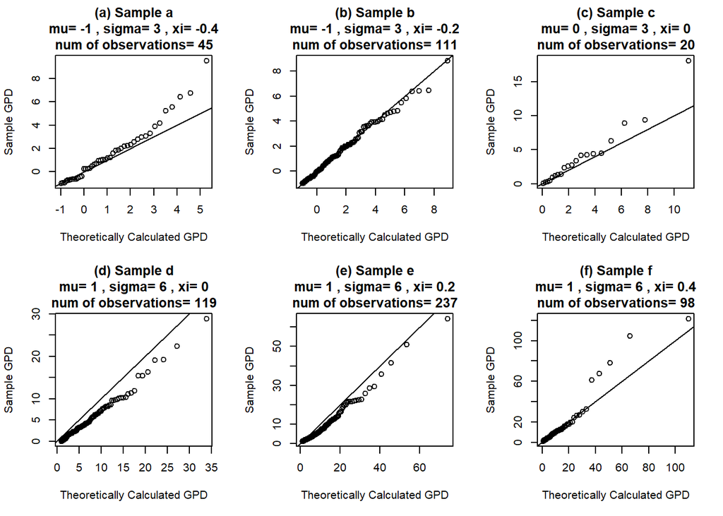

Figure 1: Comparing externally generated gpd (supplied with claimed parameters) with a theoretic gpd calculated from the same claimed parameters

Each figure in Figure 1 shows a line y=x, with the points of the gpd shown in relation to it. If the Sample GPD is actually distributed as a GPD, with the stated parameters, the points of the sample and the theoretical GPD should fall around this line.

With this in mind, Sample b and e’s parameters are correct.

Samples a (xi<0), c (xi=0), and f (xi>0) follow the same pattern. The majority of the quantiles looks correct, but the right hand tail looks heavier in the Sample. It is also the case that these samples have the fewest observations. I would be tempted to accept the parameters are correct, but winsorise the data if I needed to use it.

Sample d is consistently under the line so I think its parameters are erroneous.

### Question 4

*For this question, all R code should be displayed only within the appendix, not in the main report.*

A hydrologist is interested in understanding the river flow at a location that is historically prone to flooding. There is a river flow gauge nearby which measures river flow in units of cubic meters per second ($\text{m}^3/\text{s}$ or cumecs). Based on her knowledge of other rivers, the hydrologist proposes that for this river gauge:

- the distribution of river flow values is constant over time
- for river flows exceeding 75 cumecs, it is appropriate to model these data as independent and identically distributed GPD($\sigma =29.7$, $\xi=0.62$, $u = 0$).

Use `riverflow_2015-2024.csv` to conduct an exploratory investigation of whether these proposals are valid for the dataset provided. Summarise your findings in 250-350 words, supporting these with a collection of 4 visualisations/figures.

**TipSet yourself up for success**

Does your answer contain:

This section of the course work focuses on exploring the distribution of the flow of a river over time. The objective is to determine whether the distribution is stationary and if a proposed distribution fits the data.

I have an a piori assumption that the data would have seasonality. In order to check this and to start to understand the data, I plot the data Figure 2. The figure shows substantial outliers and seasonality, with local peaks in what looks like Q2 and end Q3. [Wonder if could use fourier transforms to find a frequency (don’t remember how to do that).]

Seasonality should be consistent on an annual basis, hence splitting the data into one year periods makes sense. In addition, given the outliers, it could be the case that the best way to think about this data is as a continuous distribution plus a rare jump process. It makes sense to analyse this using a box plot which nicely gives non-model based analysis of the core of the distribution. The box plots are shown in Figure 3.

It wasn’t clear to me if there would be a dependence on when the year points would start, so I made this a variable (start_date) in the code. It turns out it doesn’t matter. This can be more easily observed by looking at changes in Table 1 as the start-date is changed. I settle on keeping start_date as the start date of the data in order to have 10, rather than 9, sets of annual data.

The outliers in Figure 3 squash the data inside the whiskers so the visual information is of limited value. The statistics in Table 1 provide more useful information on the core of the distribution. The data implies that there is an increasing drift in the ‘non-jumpy’ data, i.e., the median, mean, Q1 and Q3 have a positive gradient.

To explore this further, I made a simple attempt to de-trend the data. To first test the observation, I fitted a linear model for the best fit median flow in a year block vs year block. The results are show in Figure 4 (a). There is a clear linear relationship.

I then subtract the model implied median from the data, subtracting a single number for each annual data block. I redo the box-plots Figure 4 (b) and statistics Table 2.

Table 2 shows the median, mean, Q1 and Q3 are consistent and hence, excluding the fat tails or jump process, the core is likely to be stationary.

**Simple Plot**

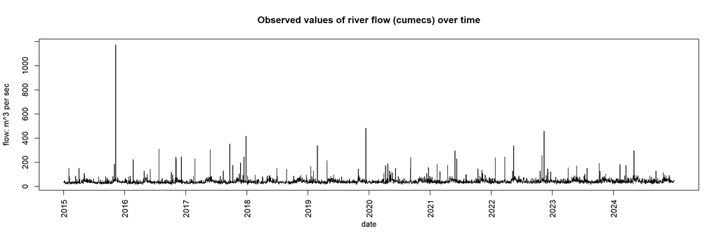

Figure 2: Observed river flow in cumecs over a 10 year period

**Box Plot**

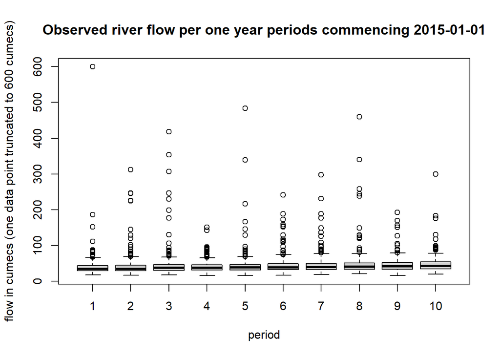

Figure 3: Box plots of observed river flow by one year periods.

**Stats**

| Periods | Mean | Lower_Whisker | Q1 | Median | Q3 | Upper_Whisker |
| --- | --- | --- | --- | --- | --- | --- |
| 1 | 39.89 | 17.36 | 28.61 | 34.05 | 43.86 | 66.25 |
| 2 | 40.93 | 16.48 | 28.39 | 34.35 | 44.65 | 68.76 |
| 3 | 43.93 | 16.93 | 30.26 | 36.76 | 46.14 | 67.08 |
| 4 | 40.83 | 15.74 | 31.22 | 37.41 | 45.29 | 65.08 |
| 5 | 43.39 | 15.14 | 31.38 | 38.60 | 46.61 | 68.95 |
| 6 | 43.95 | 16.06 | 32.05 | 38.24 | 49.02 | 74.34 |
| 7 | 44.71 | 18.53 | 31.96 | 39.51 | 50.04 | 76.53 |
| 8 | 47.32 | 20.32 | 33.02 | 40.65 | 51.13 | 76.29 |
| 9 | 45.23 | 15.82 | 33.38 | 41.69 | 51.76 | 78.73 |
| 10 | 46.79 | 19.90 | 34.58 | 42.29 | 53.54 | 77.91 |

Table 1: Summary stats for each of the periods in Figure 3

**De-trended Model & Box Plots**

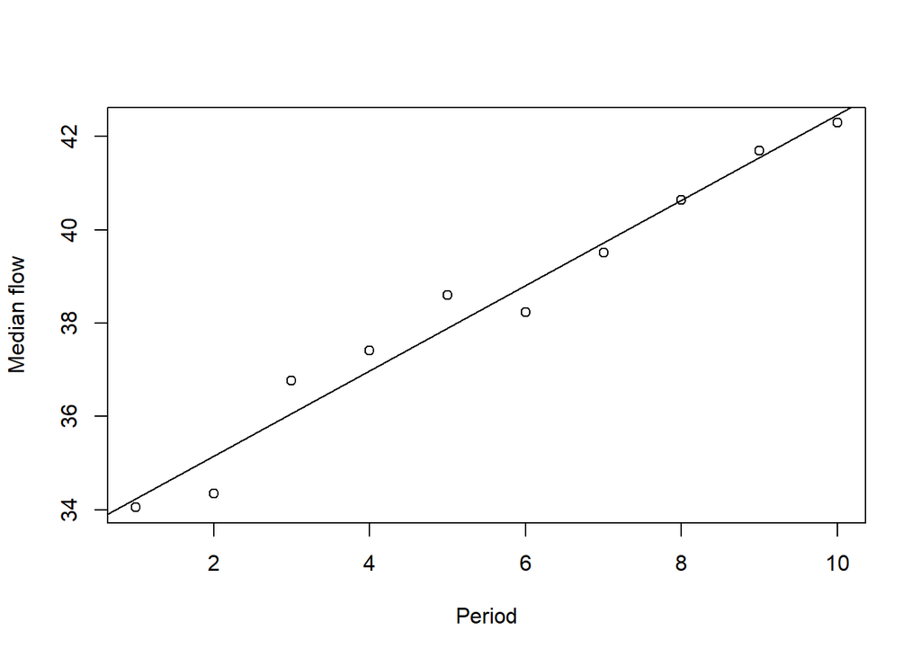

(a) A linear model for the median of a period

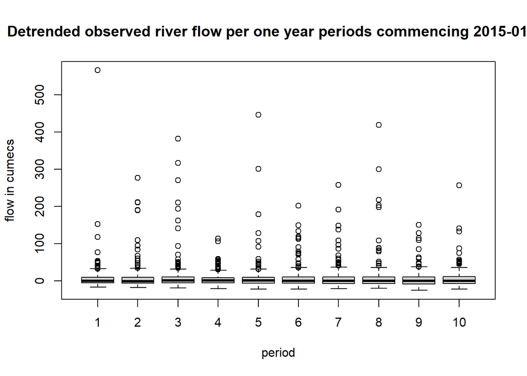

(b) Detrended box plots obtained by subtracting the model from observed flows

Figure 4: De-trending the periodic flow data by the period medians

*De-trend Summary Stats*

| Periods | Mean | Lower_Whisker | Q1 | Median | Q3 | Upper_Whisker |
| --- | --- | --- | --- | --- | --- | --- |
| 1 | 5.65 | -16.88 | -5.62 | -0.19 | 9.63 | 32.02 |
| 2 | 5.78 | -18.67 | -6.76 | -0.80 | 9.49 | 33.61 |
| 3 | 7.86 | -19.13 | -5.81 | 0.69 | 10.07 | 31.01 |
| 4 | 3.85 | -21.24 | -5.76 | 0.43 | 8.31 | 28.10 |
| 5 | 5.49 | -22.75 | -6.52 | 0.70 | 8.72 | 31.06 |
| 6 | 5.14 | -22.75 | -6.76 | -0.57 | 10.21 | 35.53 |
| 7 | 4.99 | -21.19 | -7.77 | -0.22 | 10.32 | 36.80 |
| 8 | 6.68 | -20.32 | -7.62 | 0.00 | 10.49 | 35.65 |
| 9 | 3.67 | -25.73 | -8.17 | 0.14 | 10.20 | 37.17 |
| 10 | 4.32 | -22.57 | -7.89 | -0.18 | 11.07 | 35.44 |

Table 2: Summary stats for each of the periods in Figure 4

**Model river flows greater than 75 cumecs as a GPD**

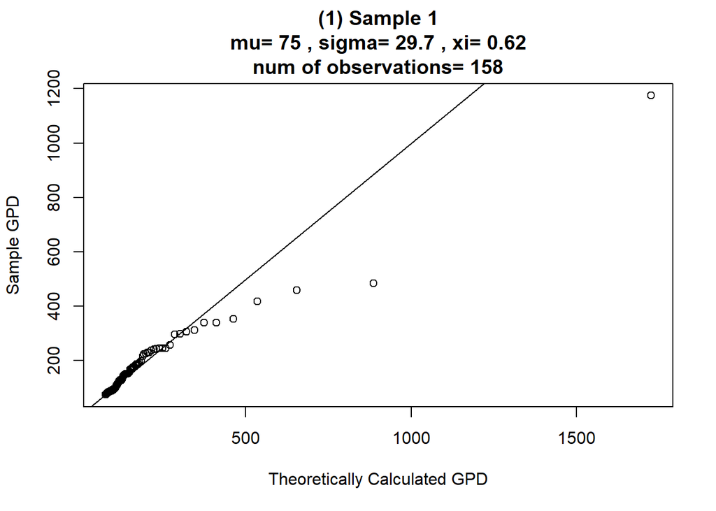

Figure 5: QQ plot of sample data above mu, versus proposed gpd (mu, sigma, xi)

**TipSet yourself up for success**

- Does your document render without any formatting issues?

## Question 5 Reflective Summary

Describe, evidence and reflect on the process of constructing the visualisations in your answer to Question 4.

Your response should be 300-400 words and might, for example, comment on:

- why you chose these forms of visualisation and what alternatives you considered;
- a challenge you faced or something that you learned while making the visualisations;
- how you might approach this task differently with more time or for a different intended audience.

**TipSet yourself up for success**

Does your response:

- describe how you engaged with the visualisation activity;
- give specific evidence of that engagement;
- critically reflection on that engagement?

**Reflections**

In the answer to question 4, the engagement with the visualisation activity, and the reasons why the plots were chosen is explained. The evidence of engagement is via the code blocks to create the various plots and figures, which are located in the appendix.

I had to look up how to split the data for the box plot into periods and how to center the table stats. So learning ‘cut’ will be very useful (as was par in a previous question). Most of the rest of the knowledge came from the data science lectures. What really took me a long time (though the question doesn’t ask this, is the writing of formula and working out the bijective conditions in Q1).

What I would have liked to do was some kind of spectral analysis of the data to find a frequency to the seasonality. I was not satisfied with the simple de-trending. I would have liked to have mixed that with another jumpy process (bi-direction - though this would have meant dependence of the jump on the value of the continuous distribution as the flow can’t go negative.)

However given the scope of the assignment and my current level of knowledge, this would not have been practical.

In felt my conclusion about stationarity was weak as it only used the de-trended box plot stats. I don’t know if there is another method that is typically employed to provide some quantitative metrics or confidence intervals. Given more time, this would have been interesting to research and then reference. Hopefully this is something we learn on in the Masters.

With the second part of question 4, I initially made a mistake with the mu=75 parameter. I had not subtracted it from the flow data and so my QQ plot didn’t lay on the y=x line. I only discovered the issue by trial and error when seeing if I could manually fit better parameters.

Another extension would be to write a function to fit the parameters given the observations.

Generally I have found the RStudio help to be quite user unfriendly, but there is much better help and context specific documentation provided by your LLM of choice.

I also would have preferred not to spend the time learning R which is not used in industry outside of biology, but to have stayed with Python. There is already a lot to learn, without spending time on something which I wont use outside of the course.

Leaving aside R, it was useful to learn qmd, though in the finance and asset management world I have only seen people use Jupyter. I have always had people to do the reports, so it is good to learn how to use this and the formula writing for myself. I am also happy that qmd can be used with Python, so that is not a wasted skill.

When submitting this on Sunday 11th Oct, I also realised what renders in html may not render in pdfs.

*End of Assessment.*

# Code Appendix

```r
# --- PLOT FUNC
gpd_qq_plot = function(sample, mu, sigma, xi, id){

  num_points = length(sample)
  sorted_sample = sort(sample)

  # feed in a set of probabilities to invert to gpd using $F^{-1}$
  prob_points = ppoints(num_points)
  theoretic_quantiles = qgpd(prob_points, xi, mu, sigma)

  plot(
    theoretic_quantiles,
    sorted_sample,
    main=paste0(
      '(', id, ') Sample ',id,
      '\nmu= ', mu, ' , sigma= ', sigma, ' , xi= ', xi,
      '\nnum of observations= ', num_points
    ),
    xlab='Theoretically Calculated GPD',
    ylab='Sample GPD'
  )

  abline(a=0, b=1) # help is not helpful, doesn't tell you which is intercept, or slope
}

# ---


samples <- read.csv('gpd_samples.csv')
# head(samples)
sample_ids = unique(samples$set_id)
num_sample_ids = length(sample_ids)

params <- read.csv('gpd_parameters.csv')
# head(params)

# have dynamic num of samples so layout-ncol doesn't work
par(mfrow=c(2,num_sample_ids/2))  # ok, so i need to know there is 6 anyway...

for (id in sample_ids){
  sample = samples$value[samples$set_id == id]

  param_set = params[params$id == id, ]
  mu = param_set$u
  sigma = param_set$sigma
  xi = param_set$xi

  gpd_qq_plot(sample, mu, sigma, xi, id)

}



flow_data <- read.csv('riverflow_2015_2024.csv', na.strings = c("", "NA"))
# unlikely river flow distribution is stationary, expect different behavior e.g., in winter vs summer

# plot flow vs time to see what we are dealing with

# names(flow_data) #  not sure what baseline_mean is

# so plot doesn't work as missing data

num_na_date = sum(is.na(flow_data$date))
num_na_flow = sum(is.na(flow_data$flow))
# print(c(num_na_flow, num_na_date))

len_date = length(flow_data$date)
len_flow = length(flow_data$flow)
# print(c(len_date, len_flow))


# confused - check blanks? add para to read.csv
# not missing, so inf?

# head(flow_data)
# date is str...
dates <- as.Date(flow_data$date)

plot(
  x=dates,
  y=flow_data$flow,
  xlab='date',
  ylab='flow: m^3 per sec',
  type='l',
  xaxt='n',
  main= 'Observed values of river flow (cumecs) over time'
)

axis.Date(1, at = seq(min(dates), max(dates), by = "year"), format = "%Y", las=2)

start_date = as.Date("2015-01-01")
boundaries <- seq(start_date, max(dates), by='year')
# print(boundaries)
if ( format(start_date, '%m')=='01' & format(start_date, '%d')=='01' ){
  boundaries = c(boundaries, as.Date("2025-01-01"))
}
# print(boundaries)

periods <- cut(dates, breaks=boundaries, right=FALSE, labels=FALSE)

# print(length(dates))
# print(length(periods))

# join data then trim to keep rows periods != NA
box_data = data.frame(dates = dates, flow = flow_data$flow, periods=periods)
# print(dim(box_data))
box_data = box_data[!is.na(box_data$periods), ]
# print(dim(box_data))

#boxplot(flow~periods, data = box_data)
# winsorize at 600

winsor_cap = 600
box_data$flow = pmin(box_data$flow, winsor_cap)
my_boxplot <- boxplot(
  flow ~ periods,
  data = box_data,
  main = paste0('Observed river flow per one year periods commencing ', start_date),
  xlab = 'period',
  ylab = 'flow in cumecs (one data point truncated to 600 cumecs)'
  )

means <- aggregate(
  flow ~ periods,
  data = box_data,
  mean
)
s_stats <- data.frame(
  Periods = my_boxplot$names,
  Mean = means$flow,
  Lower_Whisker = my_boxplot$stats[1, ],
  Q1 = my_boxplot$stats[2, ],
  Median = my_boxplot$stats[3, ],
  Q3 = my_boxplot$stats[4, ],
  Upper_Whisker = my_boxplot$stats[5, ]
)

knitr::kable(
  s_stats,
  digits=2,
  align = 'c'
)

cut_off<-75
# data was offset, hadn't minused the cutoff before
flow_samples <- flow_data$flow[flow_data$flow > cut_off]
# head(flow_samples)
# length(flow_samples)

mu<-cut_off
sigma<-29.7
xi<-0.62
id<-1

gpd_qq_plot(sample=flow_samples, mu=mu, sigma=sigma, xi=xi, id=id)


# quick look at de-trend
medians <- aggregate(
  flow ~ periods,
  data = box_data,
  median
)


trend <- lm(flow ~ periods, data = medians)

plot(
  medians$periods,
  medians$flow,
  xlab = "Period",
  ylab = "Median flow"
)

abline(trend)

box_data$detrended_flow <- box_data$flow - predict(trend, newdata = box_data)

my_boxplot_detrended <- boxplot(
  detrended_flow ~ periods,
  data = box_data,
  main = paste0('Detrended observed river flow per one year periods commencing ', start_date),
  xlab = 'period',
  ylab = 'flow in cumecs'
  )


#
detrended_means <- aggregate(
  detrended_flow ~ periods,
  data = box_data,
  mean
)

s_stats_detrended <- data.frame(
  Periods = my_boxplot_detrended$names,
  Mean = detrended_means$detrended_flow,
  Lower_Whisker = my_boxplot_detrended$stats[1, ],
  Q1 = my_boxplot_detrended$stats[2, ],
  Median = my_boxplot_detrended$stats[3, ],
  Q3 = my_boxplot_detrended$stats[4, ],
  Upper_Whisker = my_boxplot_detrended$stats[5, ]
)

knitr::kable(
  s_stats_detrended,
  digits=2,
  align = 'c'
)
```